# git and GitHub

[figure not shown]

## Acknowledgements

Parts of this presentation are based on [these slides](https://sta199-f22-1.github.io/slides/02-meet-the-toolkit.html) by Dr. Mine Çetinkaya-Rundel.

## Today’s goals

1. What is git?
2. What is versioning?
3. Local workflow of git
4. What is GitHub?
5. Local/remote workflow of git + GitHub
6. Setting up git + GitHub workflows in RStudio
7. Tips and resources

## What is git?

[figure not shown]

- Git is a version control system – like “Track Changes” features from Microsoft Word, on steroids
- It’s not the only version control system, but it’s a very popular one

## Versioning

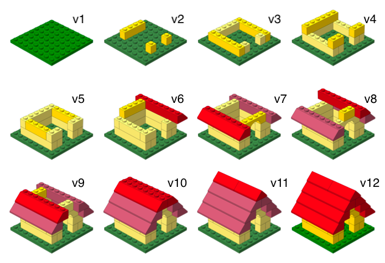

## Versioning

### with human readable messages

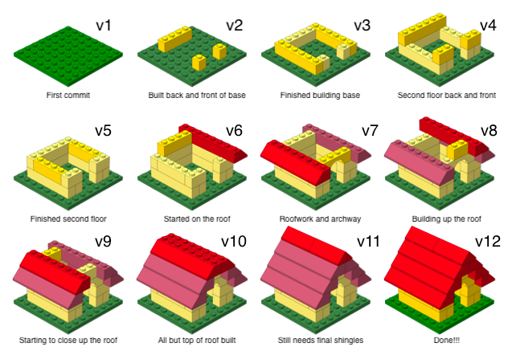

## How does a git worflow look like in your local computer?

1. Start a new git project typing in the terminal `git init`
2. Create/modify folders and files inside of that git project directory
3. Stage these changes typing in the terminal `git stage -A`
4. Commit these staged changes typing in the terminal `git commit -m "short yet informative message of changes made in this commit"`
5. Make more changes, repeat steps 3 and 4.

## How does a git worflow look like in your local computer?

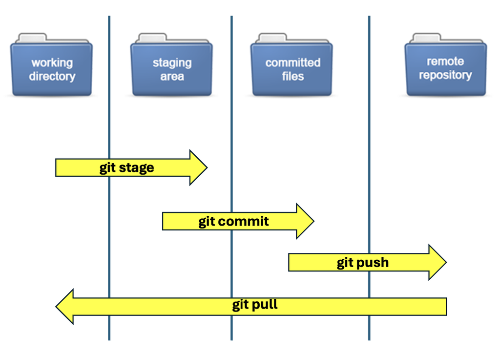

## What is GitHub?

[figure not shown]

- GitHub is the home for your Git-based projects on the internet – like DropBox but much, much better
- We will use GitHub as a platform for web hosting and collaboration (and as our course management system!)

## Local/remote workflows of git + GitHub

[figure not shown]

1. No GitHub

[figure not shown]

2. GitHub clone (you own it)

[figure not shown]

3. GitHub clone (someone else owns, you are collaborator)

[figure not shown]

## Local/remote workflows of git + GitHub in this class

In this class, you will, for the most part, be working alone in GitHub repos that you own (option 2 from previous slide).

[figure not shown]

## Local/remote workflow of git + GitHub we will use

After making sure your local git is connected to a GitHub repository through `git clone`:

1. Follow same steps as for local workflow
2. After committing changes, “upload” them to the GitHub repo typing in the terminal `git push`
3. If there were any changes in the GitHub repo you did not have locally, “download” them to your local copy typing in the terminal `git pull`

## Setting up git + GitHub workflows in RStudio

For that, we will follow the [New project, GitHub first](https://happygitwithr.com/new-github-first.html) workflow (see link above for detailed instructions).

1. Make a repo on GitHub
2. New RStudio Project via git clone
3. Make local changes, save, commit
4. Push your local changes to GitHub

## Setting up git + GitHub workflows in RStudio

Every single new coding exercise will follow the above workflow, in a way that you will have one git/GitHub repo in your own GitHub for each exercise.

## git and GitHub tips

- The workflows delineated above that include **stage, commit, push, and pull** are very simple.
- git/GitHub can handle a lot more complex workflows including branching, forking, pull requests, etc.
- For now, we will focus on the simple workflow above, and will explore more complex workflows as needed.

## Wisdom notes

- Commit often (multiple times a day), push less often (few times a day)
- Before pushing, always pull first!

## git and GitHub resources

- There is a great resource for working with git and R: [happygitwithr.com](http://happygitwithr.com/).
- We’ll make extensive use of this resource, please get acquainted.
- [git/GitHub cheatsheet](https://training.github.com/downloads/github-git-cheat-sheet.pdf)

## Useful Git/Github terminal commands

`git pull` to start your work fresh with most recent version from remote  
`git status` to check the status of git  
`git stage -A` to stage changes  
`git commit -m "commitMessage"` to make a commit  
`git push` to send changes from **local** to **remote**  
`git log --oneline` to see summarized list of commits (push `q` to quit console when done)

## Now, let’s get all this going on your own laptops